# Vroom Benchmarks

**This is a revision of `vroom`’s official benchmarks, found at https://vroom.r-lib.org/articles/benchmarks.html. They have been modified to include several Apache Arrow-based projects for comparison. Additions to the original document’s text are indicated in bold.**

# Reading delimited files

The following benchmarks all measure reading delimited files of various sizes and data types. Because vroom delays reading the benchmarks also do some manipulation of the data afterwards to try and provide a more realistic performance comparison.

Because the `read.delim` results are so much slower than the others they are excluded from the plots, but are retained in the tables.

## Taxi Trip Dataset

This real world dataset is from Freedom of Information Law (FOIL) Taxi Trip Data from the NYC Taxi and Limousine Commission 2013, originally posted at http://chriswhong.com/open-data/foil_nyc_taxi/. It is also hosted on [archive.org](https://archive.org/details/nycTaxiTripData2013).

The first table trip_fare_1.csv is 1.55G in size.

```
#> Observations: 14,776,615
#> Variables: 11
#> $ medallion       <chr> "89D227B655E5C82AECF13C3F540D4CF4", "0BD7C8F5B...
#> $ hack_license    <chr> "BA96DE419E711691B9445D6A6307C170", "9FD8F69F0...
#> $ vendor_id       <chr> "CMT", "CMT", "CMT", "CMT", "CMT", "CMT", "CMT...
#> $ pickup_datetime <chr> "2013-01-01 15:11:48", "2013-01-06 00:18:35", ...
#> $ payment_type    <chr> "CSH", "CSH", "CSH", "CSH", "CSH", "CSH", "CSH...
#> $ fare_amount     <dbl> 6.5, 6.0, 5.5, 5.0, 9.5, 9.5, 6.0, 34.0, 5.5, ...
#> $ surcharge       <dbl> 0.0, 0.5, 1.0, 0.5, 0.5, 0.0, 0.0, 0.0, 1.0, 0...
#> $ mta_tax         <dbl> 0.5, 0.5, 0.5, 0.5, 0.5, 0.5, 0.5, 0.5, 0.5, 0...
#> $ tip_amount      <int> 0, 0, 0, 0, 0, 0, 0, 0, 0, 0, 0, 0, 0, 0, 0, 0...
#> $ tolls_amount    <dbl> 0.0, 0.0, 0.0, 0.0, 0.0, 0.0, 0.0, 4.8, 0.0, 0...
#> $ total_amount    <dbl> 7.0, 7.0, 7.0, 6.0, 10.5, 10.0, 6.5, 39.3, 7.0...
```

### Taxi Benchmarks

code: bench/taxi

All benchmarks were run on a Amazon EC2 [m5.4xlarge](https://aws.amazon.com/ec2/instance-types/m5/) instance with 16 vCPUs and an [EBS](https://aws.amazon.com/ebs/) volume type.

**In order to test the GPU-based `cudf` library, these benchmarks were run on an NVIDIA DGX workstation with the following specifications:**

**CPU:**

- **Intel(R) Xeon(R) CPU E5-2698 v4 @ 2.20GHz**
- **256 GB RAM (2400 MHz), SSD**

**GPU:**

- **4 NVIDIA V100 GPUs, 5,120 CUDA cores each**
- **32 GB memory per GPU**

**R and all necessary system dependencies are installed via `conda`. Benchmarks were run with development versions of `arrow` and `cudf` and released versions of all other packages.**

The benchmarks labeled `vroom_base` uses `vroom` with base functions for manipulation. `vroom_dplyr` uses `vroom` to read the file and dplyr functions to manipulate. `data.table` uses `fread()` to read the file and `data.table` functions to manipulate and `readr` uses `readr` to read the file and `dplyr` to manipulate. By default vroom only uses Altrep for character vectors, these are labeled `vroom(altrep: normal)`. The benchmarks labeled `vroom(altrep: full)` instead use Altrep vectors for all supported types and `vroom(altrep: none)` disable Altrep entirely.

**The `arrow` benchmarks are divided into three types: (1) read into an R data.frame using `arrow` and then all subsequent processing happens with `dplyr`; (2) same but using `data.table` to aggregate in R; (3) data is held in an Arrow Table and computed on in Arrow to the extent possible (as of writing, this means selecting and filtering happen in Arrow but aggregation requires pulling a window of data into an R `data.frame`.)**

**`cudf` is a Python package, here called from R using `reticulate`, and results are pulled into R using the `arrow` R package’s methods.**

The following operations are performed.

- The data is read
- `print()` - *N.B. read.delim uses `print(head(x, 10))` because printing the whole dataset takes > 10 minutes*
- `head()`
- `tail()`
- Sampling 100 random rows
- Filtering for “UNK” payment, this is 6434 rows (0.0435% of total).
- Aggregation of mean fare amount per payment type.

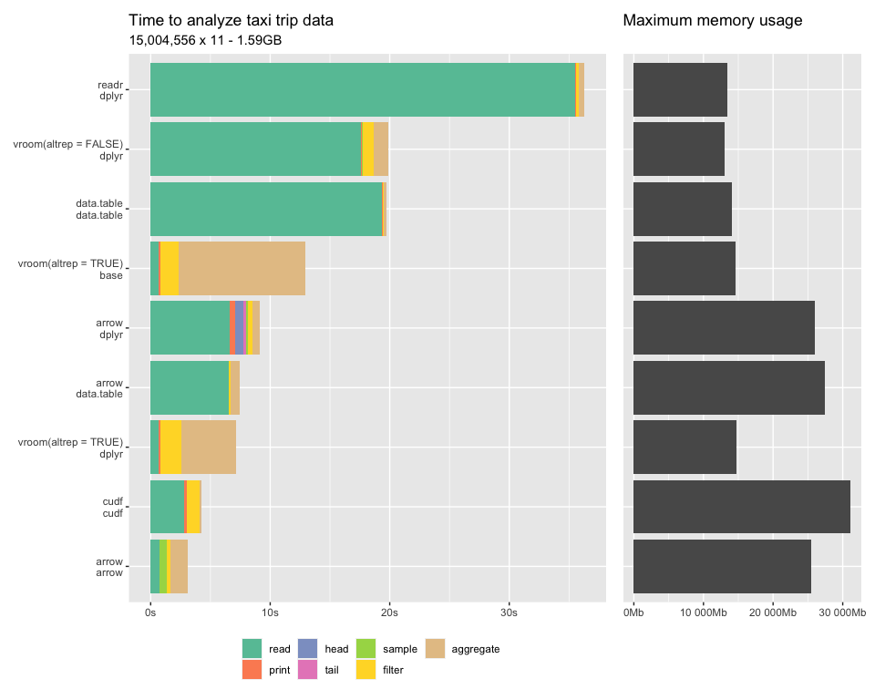

| reading package | manipulating package | altrep | memory | read | print | head | tail | sample | filter | aggregate | total |
| --- | --- | --- | --- | --- | --- | --- | --- | --- | --- | --- | --- |
| read.delim | base |  | 13.1GB | 1m 22.6s | 7ms | 1ms | 1ms | 1ms | 1.2s | 895ms | 1m 24.8s |
| readr | dplyr |  | 13.1GB | 35.5s | 95ms | 1ms | 1ms | 10ms | 217ms | 498ms | 36.3s |
| vroom | dplyr | FALSE | 12.7GB | 17.6s | 103ms | 1ms | 1ms | 9ms | 946ms | 1.2s | 19.9s |
| data.table | data.table |  | 13.7GB | 19.4s | 16ms | 1ms | 1ms | 1ms | 145ms | 226ms | 19.8s |
| vroom | base | TRUE | 14.3GB | 676ms | 118ms | 1ms | 1ms | 1ms | 1.5s | 10.6s | 12.9s |
| arrow | dplyr |  | 25.4GB | 6.6s | 433ms | 657ms | 231ms | 179ms | 382ms | 598ms | 9.1s |
| arrow | data.table |  | 26.7GB | 6.5s | 14ms | 1ms | 1ms | 1ms | 120ms | 778ms | 7.4s |
| vroom | dplyr | TRUE | 14.3GB | 694ms | 127ms | 1ms | 1ms | 10ms | 1.7s | 4.6s | 7.1s |
| cudf | cudf |  | 30.4GB | 2.8s | 229ms | 4ms | 4ms | 7ms | 1.1s | 130ms | 4.2s |
| arrow | arrow |  | 24.9GB | 723ms | 45ms | 1ms | 2ms | 610ms | 309ms | 1.4s | 3.1s |

(*N.B. Rcpp used in the dplyr implementation fully materializes all the Altrep numeric vectors when using `filter()` or `sample_n()`, which is why the first of these cases have additional overhead when using full Altrep.*).

## All numeric data

All numeric data is really a worst case scenario for vroom. The index takes about as much memory as the parsed data. Also because parsing doubles can be done quickly in parallel and text representations of doubles are only ~25 characters at most there isn’t a great deal of savings for delayed parsing.

For these reasons (and because the data.table implementation is very fast) vroom is a bit slower than fread for pure numeric data.

However because vroom is multi-threaded it is a bit quicker than readr and read.delim for this type of data.

### Long

code: bench/all_numeric-long

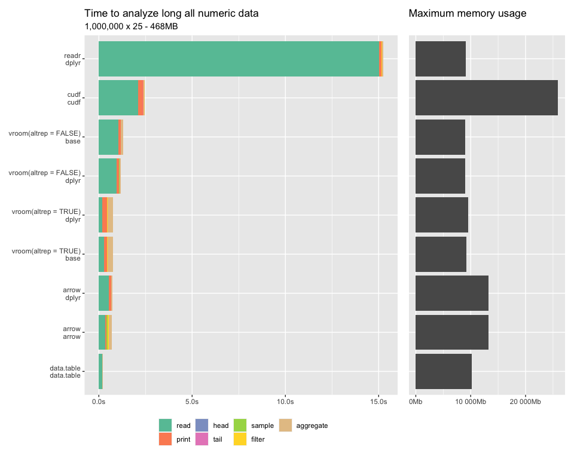

| reading package | manipulating package | altrep | memory | read | print | head | tail | sample | filter | aggregate | total |
| --- | --- | --- | --- | --- | --- | --- | --- | --- | --- | --- | --- |
| read.delim | base |  | 10.81GB | 1m 42.2s | 1.3s | 1ms | 1ms | 1ms | 4s | 44ms | 1m 47.5s |
| readr | dplyr |  | 8.9GB | 15s | 117ms | 1ms | 1ms | 10ms | 18ms | 92ms | 15.3s |
| cudf | cudf |  | 25.33GB | 2.1s | 271ms | 5ms | 4ms | 9ms | 29ms | 35ms | 2.4s |
| vroom | base | FALSE | 8.76GB | 1s | 127ms | 1ms | 1ms | 3ms | 12ms | 109ms | 1.3s |
| vroom | dplyr | FALSE | 8.77GB | 950ms | 138ms | 1ms | 1ms | 11ms | 22ms | 58ms | 1.2s |
| vroom | dplyr | TRUE | 9.29GB | 192ms | 234ms | 1ms | 1ms | 12ms | 49ms | 270ms | 756ms |
| vroom | base | TRUE | 9.05GB | 271ms | 172ms | 1ms | 1ms | 3ms | 37ms | 269ms | 750ms |
| arrow | dplyr |  | 12.89GB | 539ms | 111ms | 1ms | 1ms | 11ms | 18ms | 61ms | 739ms |
| arrow | arrow |  | 12.89GB | 345ms | 71ms | 1ms | 2ms | 67ms | 55ms | 158ms | 697ms |
| data.table | data.table |  | 9.92GB | 169ms | 14ms | 1ms | 1ms | 3ms | 9ms | 26ms | 220ms |

### Wide

code: bench/all_numeric-wide

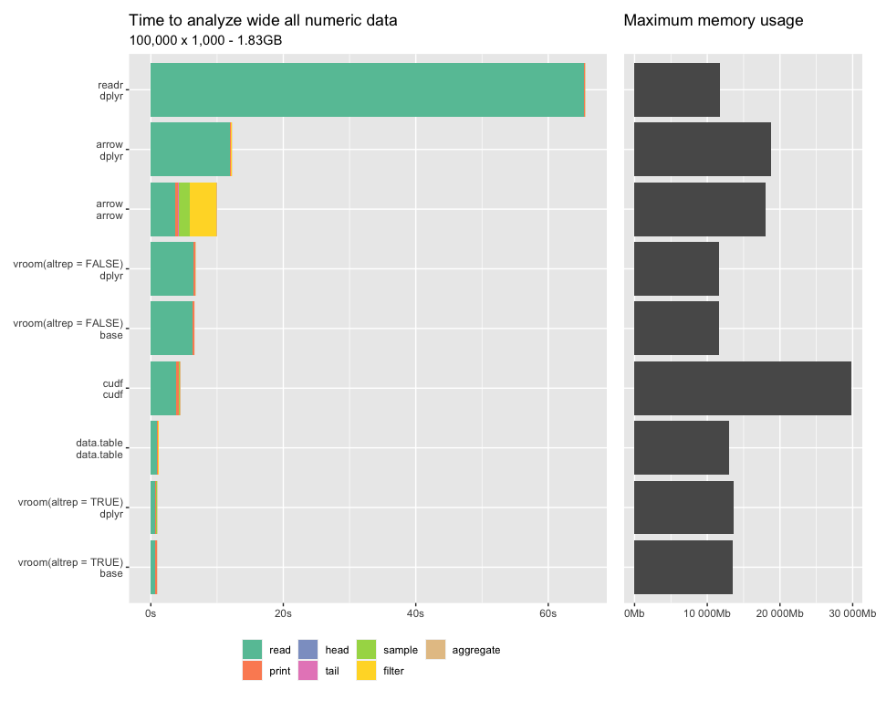

| reading package | manipulating package | altrep | memory | read | print | head | tail | sample | filter | aggregate | total |
| --- | --- | --- | --- | --- | --- | --- | --- | --- | --- | --- | --- |
| read.delim | base |  | 20.5GB | 7m 49.1s | 174ms | 9ms | 9ms | 10ms | 90ms | 6ms | 7m 49.4s |
| readr | dplyr |  | 11.4GB | 1m 5.3s | 163ms | 3ms | 3ms | 31ms | 16ms | 41ms | 1m 5.6s |
| arrow | dplyr |  | 18.3GB | 12s | 155ms | 2ms | 2ms | 20ms | 16ms | 50ms | 12.2s |
| arrow | arrow |  | 17.6GB | 3.7s | 422ms | 3ms | 146ms | 1.6s | 4s | 128ms | 10s |
| vroom | dplyr | FALSE | 11.3GB | 6.5s | 191ms | 2ms | 3ms | 27ms | 18ms | 48ms | 6.7s |
| vroom | base | FALSE | 11.3GB | 6.4s | 216ms | 3ms | 3ms | 5ms | 6ms | 8ms | 6.6s |
| cudf | cudf |  | 29.2GB | 3.8s | 388ms | 39ms | 38ms | 57ms | 89ms | 27ms | 4.5s |
| data.table | data.table |  | 12.7GB | 960ms | 143ms | 7ms | 7ms | 8ms | 8ms | 5ms | 1.1s |
| vroom | dplyr | TRUE | 13.3GB | 642ms | 199ms | 4ms | 4ms | 20ms | 23ms | 70ms | 958ms |
| vroom | base | TRUE | 13.2GB | 663ms | 232ms | 4ms | 4ms | 5ms | 13ms | 36ms | 954ms |

## All character data

code: bench/all_character-long

All character data is a best case scenario for vroom when using Altrep, as it takes full advantage of the lazy reading.

### Long

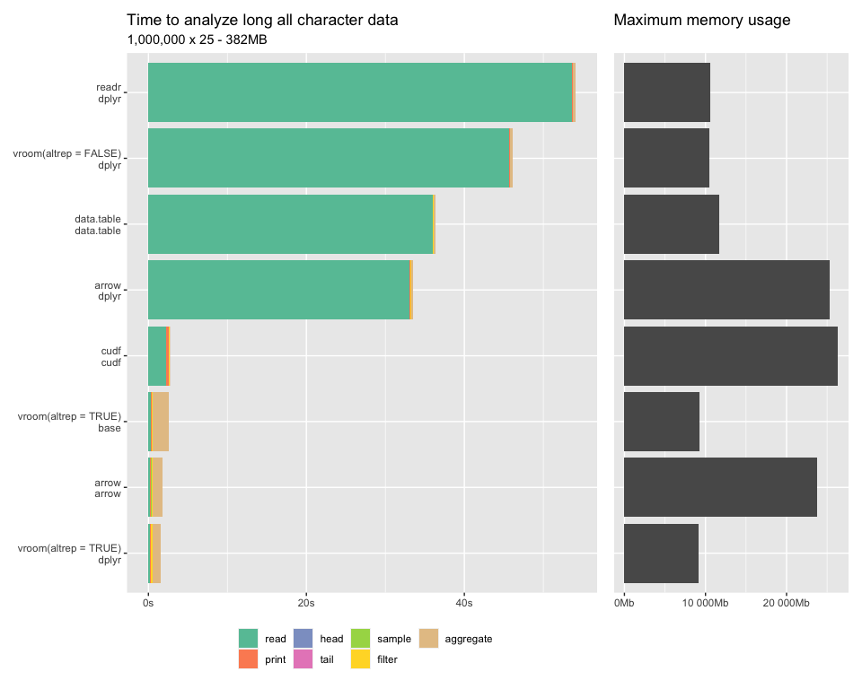

| reading package | manipulating package | altrep | memory | read | print | head | tail | sample | filter | aggregate | total |
| --- | --- | --- | --- | --- | --- | --- | --- | --- | --- | --- | --- |
| read.delim | base |  | 10.49GB | 1m 29.8s | 9ms | 1ms | 1ms | 2ms | 30ms | 434ms | 1m 30.3s |
| readr | dplyr |  | 10.29GB | 53.6s | 107ms | 1ms | 1ms | 11ms | 16ms | 371ms | 54.1s |
| vroom | dplyr | FALSE | 10.26GB | 45.7s | 107ms | 1ms | 1ms | 10ms | 16ms | 309ms | 46.1s |
| data.table | data.table |  | 11.47GB | 36s | 18ms | 1ms | 1ms | 4ms | 18ms | 290ms | 36.4s |
| arrow | dplyr |  | 24.77GB | 33.1s | 110ms | 1ms | 1ms | 11ms | 16ms | 310ms | 33.5s |
| cudf | cudf |  | 25.75GB | 2.2s | 306ms | 6ms | 5ms | 12ms | 100ms | 53ms | 2.7s |
| vroom | base | TRUE | 8.99GB | 278ms | 126ms | 1ms | 1ms | 2ms | 161ms | 2.1s | 2.6s |
| arrow | arrow |  | 23.18GB | 241ms | 70ms | 1ms | 2ms | 112ms | 64ms | 1.3s | 1.8s |
| vroom | dplyr | TRUE | 8.97GB | 179ms | 150ms | 1ms | 1ms | 9ms | 172ms | 1s | 1.6s |

### Wide

code: bench/all_character-wide

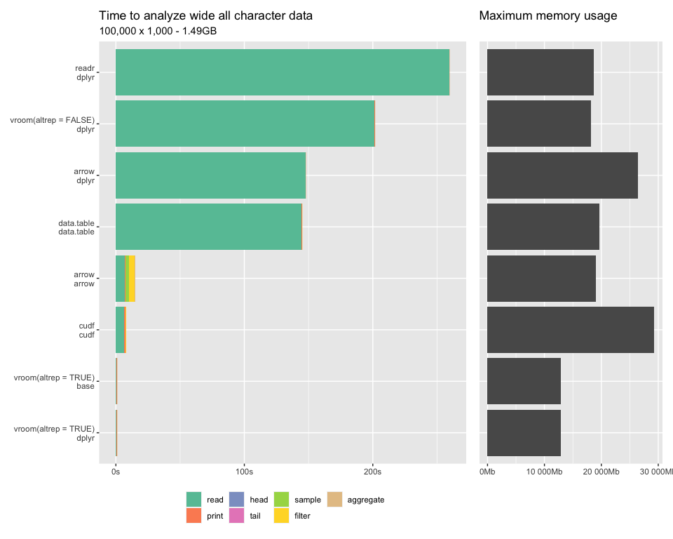

| reading package | manipulating package | altrep | memory | read | print | head | tail | sample | filter | aggregate | total |
| --- | --- | --- | --- | --- | --- | --- | --- | --- | --- | --- | --- |
| read.delim | base |  | 19.1GB | 7m 55.5s | 192ms | 9ms | 9ms | 24ms | 193ms | 62ms | 7m 56s |
| readr | dplyr |  | 18.3GB | 4m 19.6s | 159ms | 2ms | 3ms | 23ms | 31ms | 70ms | 4m 19.8s |
| vroom | dplyr | FALSE | 17.8GB | 3m 21.4s | 160ms | 2ms | 3ms | 23ms | 31ms | 56ms | 3m 21.7s |
| arrow | dplyr |  | 25.9GB | 2m 27.5s | 155ms | 2ms | 3ms | 24ms | 31ms | 57ms | 2m 27.8s |
| data.table | data.table |  | 19.2GB | 2m 24.5s | 200ms | 1ms | 1ms | 25ms | 132ms | 28ms | 2m 24.9s |
| arrow | arrow |  | 18.6GB | 6.9s | 479ms | 3ms | 123ms | 2.5s | 4.7s | 166ms | 14.9s |
| cudf | cudf |  | 28.6GB | 6.6s | 573ms | 75ms | 76ms | 200ms | 241ms | 33ms | 7.8s |
| vroom | base | TRUE | 12.6GB | 647ms | 175ms | 4ms | 4ms | 5ms | 44ms | 180ms | 1.1s |
| vroom | dplyr | TRUE | 12.6GB | 559ms | 154ms | 4ms | 4ms | 19ms | 55ms | 115ms | 907ms |

# Reading multiple delimited files

code: bench/taxi_multiple

The benchmark reads all 12 files in the taxi trip fare data, totaling 173,179,759 rows and 11 columns for a total file size of 18.4G.

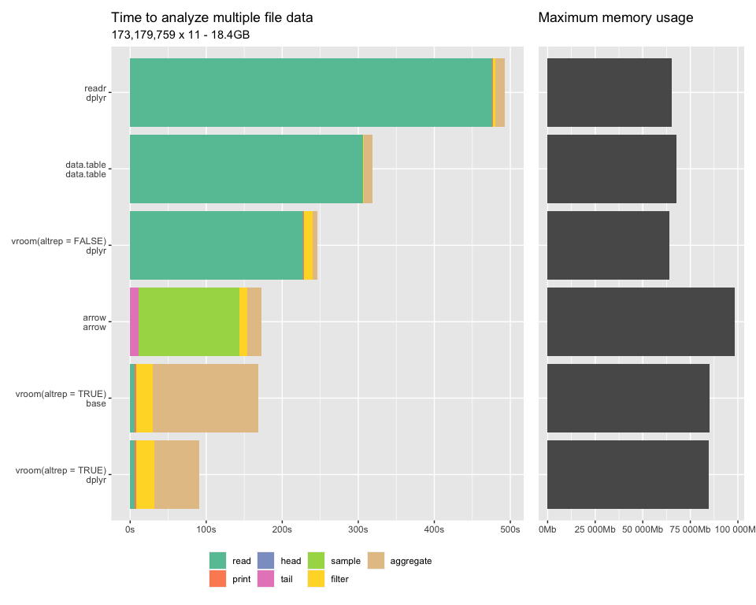

| reading package | manipulating package | altrep | memory | read | print | head | tail | sample | filter | aggregate | total |
| --- | --- | --- | --- | --- | --- | --- | --- | --- | --- | --- | --- |
| readr | dplyr |  | 63.8GB | 7m 56.6s | 93ms | 1ms | 1ms | 9ms | 3.8s | 12.7s | 8m 13.1s |
| data.table | data.table |  | 66.1GB | 5m 6.3s | 7ms | 1ms | 1ms | 1ms | 1.1s | 11s | 5m 18.4s |
| vroom | dplyr | FALSE | 62.4GB | 3m 47s | 1.7s | 1ms | 1ms | 9ms | 10.8s | 6.6s | 4m 6.2s |
| arrow | arrow |  | 96.2GB | 72ms | 36ms | 15ms | 10.5s | 2m 13.5s | 10.3s | 18.2s | 2m 52.5s |
| vroom | base | TRUE | 83GB | 5.7s | 2.5s | 1ms | 1ms | 1ms | 21.5s | 2m 19.2s | 2m 48.9s |
| vroom | dplyr | TRUE | 82.7GB | 5.6s | 2.4s | 1ms | 1ms | 8ms | 24.2s | 58.5s | 1m 30.8s |

# Reading fixed width files

**Arrow is not included in these benchmarks because currently it does not support reading fixed-width files.**

## United States Census 5-Percent Public Use Microdata Sample files

This fixed width dataset contains individual records of the characteristics of a 5 percent sample of people and housing units from the year 2000 and is freely available at https://www2.census.gov/census_2000/datasets/PUMS/FivePercent/California/all_California.zip. The data is split into files by state, and the state of California was used in this benchmark.

The data totals 2,342,339 rows and 37 columns with a total file size of 677M.

## Census data benchmarks

code: bench/fwf

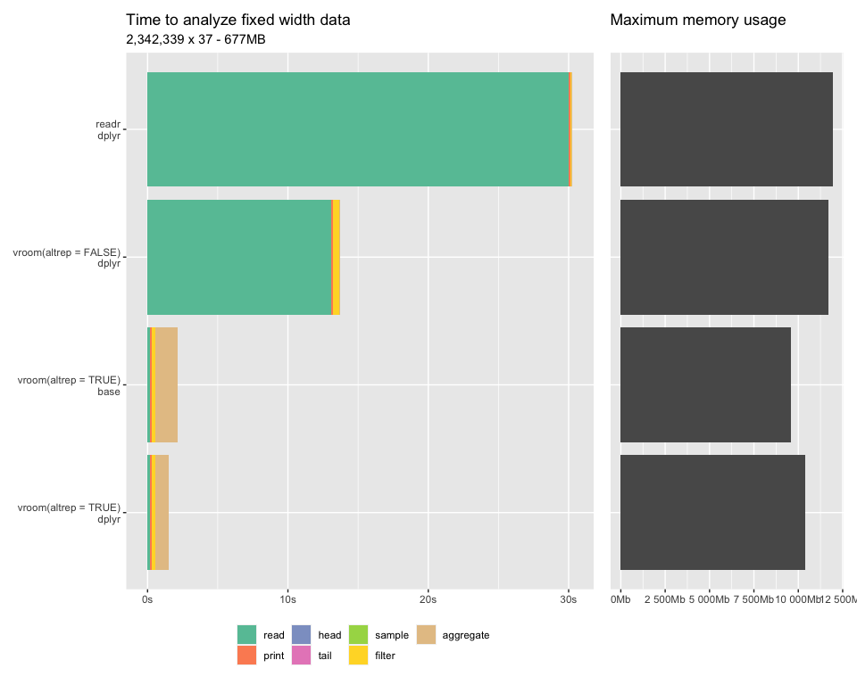

| reading package | manipulating package | altrep | memory | read | print | head | tail | sample | filter | aggregate | total |
| --- | --- | --- | --- | --- | --- | --- | --- | --- | --- | --- | --- |
| read.delim | base |  | 13.96GB | 17m 33.8s | 20ms | 1ms | 2ms | 3ms | 347ms | 93ms | 17m 34.3s |
| readr | dplyr |  | 11.69GB | 30s | 124ms | 1ms | 1ms | 14ms | 79ms | 86ms | 30.3s |
| vroom | dplyr | FALSE | 11.4GB | 13.1s | 122ms | 1ms | 1ms | 14ms | 419ms | 84ms | 13.7s |
| vroom | base | TRUE | 9.37GB | 149ms | 159ms | 1ms | 1ms | 4ms | 224ms | 1.6s | 2.1s |
| vroom | dplyr | TRUE | 10.14GB | 153ms | 158ms | 1ms | 1ms | 14ms | 237ms | 940ms | 1.5s |

# Writing delimited files

**Arrow is not included in these benchmarks because it currently only writes Feather and Parquet format, not CSV**

code: bench/taxi_writing

The benchmarks write out the taxi trip dataset in a few different ways.

- An uncompressed file
- A gzip compressed file using `gzfile()` *(readr and vroom do this automatically for files ending in `.gz`)*
- A gzip compressed file compressed with multiple threads (natively for data.table and using a `pipe()` connection to [pigz](https://zlib.net/pigz/) for the rest).
- A [Zstandard](https://facebook.github.io/zstd/) compressed file (data.table does not support this format).

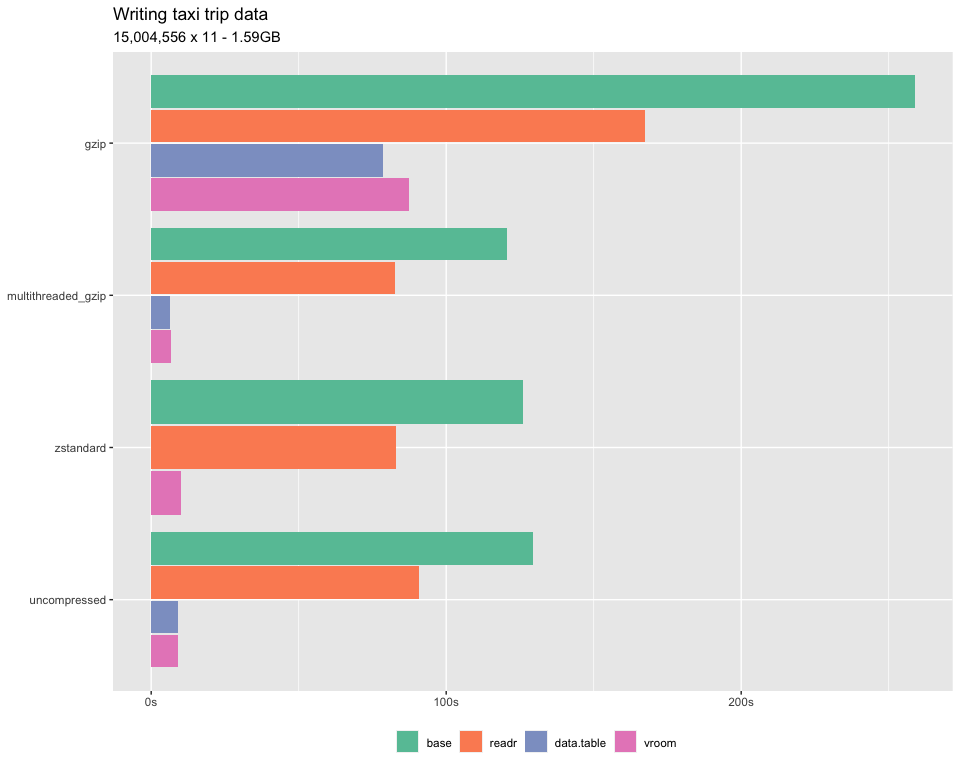

| compression | base | data.table | readr | vroom |
| --- | --- | --- | --- | --- |
| gzip | 4m 18.8s | 1m 18.5s | 2m 47.4s | 1m 27.5s |
| multithreaded_gzip | 2m 0.8s | 6.2s | 1m 22.8s | 6.7s |
| zstandard | 2m 6.2s | NA | 1m 22.9s | 10s |
| uncompressed | 2m 9.5s | 9.1s | 1m 30.8s | 9.2s |

## Session and package information